# Regression Models Course Project

Technophobe01

2015-05-23

# Executive Summary - 1974 Motor Trend Data in Review

This report was requested to enable a review of the 1974 magazine data on past car mpg performance and changes in vehicle efficiency. It addresses two core quesitons:

1. Is an automatic or manual transmission better for MPG?
2. Quantify the MPG difference between automatic and manual transmissions.

Based upon our analysis we conclude that in 1974:

1. **Manual tranmisssions were better for MPG**.
2. Transmission, weight and quarter mile time significantly influenced mpg effienciency.
3. Manual transmissions were on average **7.24 miles per gallon** more efficient that automatics.
4. The model developed is estimated to explain about **88%** of the variance of the MPG variable in the **mtcars** data set.

**Conclusion:** In 1974, cars that were lighter in weight with a manual transmission and cars that were heavier in weight with an automatic transmission had higher MPG values. See: Appendix A, Figure 2.

Note: The report source code is available via **[GitHub](https://github.com/Technophobe01/courses/tree/master/07_RegressionModels/001_CourseWork)** for deeper review.

## Data Set Description

The Motor Trend magazine data was extracted in 1974, it coverered gasoline mileage in miles per gallon (MPG), and ten aspects of vehicle design and performance for 32 vehicles (1973-74 models), the sample includes 32 vehicles and has a bias to exotic, non-US., automobiles: it includes seven Mercedes, a Porsche, a Ferrari, a Maserati and offers us us an amazing view of vehicle effiency and performance from 1974.

## Basic exploratory data analyses

|  | P.Value | Confidence | Lower.Bound | Upper.Bound |
| --- | --- | --- | --- | --- |
| **MPG ~ Transmission** | 0.001374 | 95% | -11.28 | -3.21 |

Did lower automatic transmission mpg efficiency occur in the data by random chance? To try to confirm, we performed a `t.test(mpg ~ am, data=mtcars)`. The t-test **p-value** result of **0.0013736** in combination with a confidence value of **95%**, indicate that we can be confident that the probability of chance is low. We conclude that automatic transmissions **did** have lower **MPG** in 1974 than manuals.

We checked to see if automobile weight in 1974 **correlated** with **MPG** efficiency. **Appendix A, Figure 2** shows that in 1974 automobile weight did correlate with MPG for both manual and automatic cars. We used a linear model to depict the manual and automatic trend lines.

```r
baseline <- lm(mpg ~ ., data=mtcars)
prefferedModel <- step(baseline, k=log(nrow(mtcars)))
```

[output not shown]

```r
selectedModel <- aov(mpg ~ wt*qsec*am, data=mtcars)
summary(selectedModel)
finalModel <- lm(mpg ~ wt + qsec + am + wt:am, data=mtcars)
summary(finalModel)$coef
```

[output not shown]

Thus, we conclude that when `wt` **(weight/1000lbs)** and `qsec` **(1/4 mile time)** are fixed, we can calculate the manual transmission advantage over an equivalent automatic transmission. For example, a hypetheical manual transmission car that weighs 2500 lbs has, with a qsec of 16.5 has a predicted mpg of **22.9mpg**. We can go futher an use the `finalmodel` to predict the mpg of all the vehicles in mtcars.

```r
# We can now use predict() to predict the fuel economy of hypothetical cars...
newcar = data.frame(wt=2.5, qsec=16.5, am=1)
predict(finalModel, newcar)

# Alternatively, we can use predict() to show the predicted fuel economoy of mtcars
predict(finalModel)
```

[output not shown]

## Residual Analysis / Diagnostics

To wrap up, we ran a diagnostic model (Appendix A, Figure 4), (Ref: R CookBook, Section 11.15) enablign us to verify the following underlying assumptions:

# Appendix A

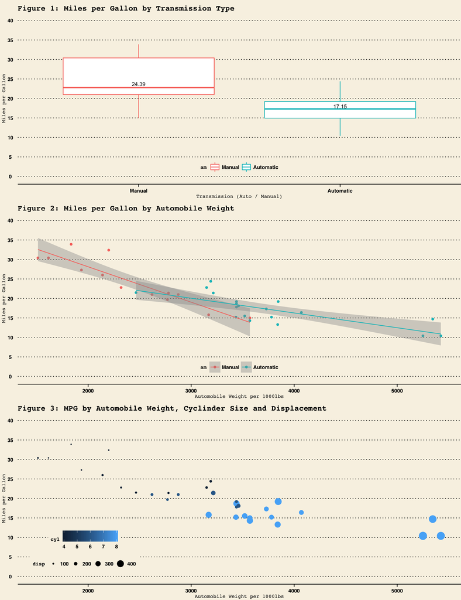

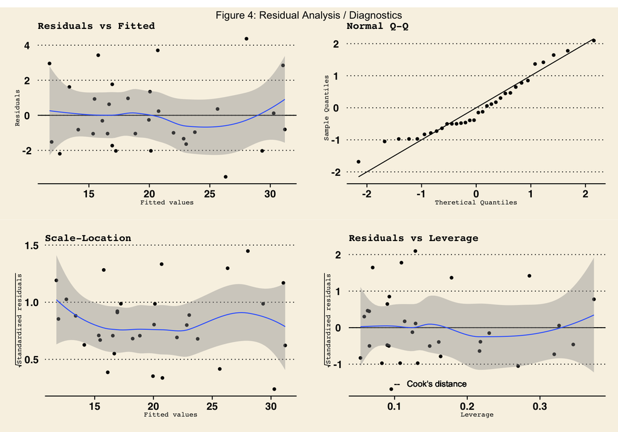

# **References**

- *The R Book*
  - By: Michael J. Crawley, Publisher: John Wiley & Sons Pub. Date: December 26, 2012, eISBN: 978-1-118-44896-0
- *R in Action*
  - By: Robert Kabacoff Publisher: Manning Publications Pub. Date: August 24, 2011, ISBN-10: 1-935182-39-0
- *Mathematical Statistics with Resampling and R*
  - By: Laura Chihara; Tim Hesterberg Publisher: John Wiley & Sons Pub. Date: September 6, 2011 Print ISBN: 978-1-11-02985-5
- *OpenIntro Statistics - 2nd Editions*
  - By: by David M Diez (Author), Christopher D Barr (Author), Mine Çetinkaya-Rundel (Author)
- *Think Stats, 2nd Edition*
  - By: Allen B. Downey Publisher: O’Reilly Media, Inc. Pub. Date: October 28, 2014 Print ISBN-13: 978-1-4919-0733-7